# Deploy a custom model to the Watson Machine Learning repository using Python function

| **Deploy a custom model to the Watson Machine Learning repository using Python function** |  |
| --- | --- |

This notebook demonstrates how to deploy a custom model that uses a non-supported framework to the `Watson Machine Learning (WML)` using a Python function. For supported model types (frameworks), refer to this [link](https://dataplatform.cloud.ibm.com/docs/content/wsj/analyze-data/pm_service_supported_frameworks.html).

You will deploy the model from the [Use statsmodels to forecast the Consumer Price Index (time series)](https://dataplatform.cloud.ibm.com/exchange/public/entry/view/1835c567cd309d54fc797900f79a60f9) notebook to the `Watson Machine Learning (WML)` repository. The notebook is in the `Watson Studio` community.

You will learn how to define a `Python function` that trains a time series model using `statsmodels`, then deploy it to the `Watson Machine Learning` repository.

The data set, [Consumer Prices](https://dataplatform.cloud.ibm.com/exchange/public/entry/view/304ff4a1704b967dd29693a4d32ba626), which is originally sourced from the [International Labour Organization](http://www.ilo.org/stat/) measures the Consumer Price Index of different countries over a period of time. The **Consumer Price Index (CPI)** is defined as a measure of the average change over time in the prices paid by urban consumers for a market basket of consumer goods and services. Forecasting this value is useful because it's a valuable economic indicator used to predict the rate of inflation. It also affects decision making pertaining to income payments.

This notebook uses Python 3.6, the `statsmodels`, and the `watson-machine-learning-client` packages.

## Learning goals

- Load data as a dataframe
  - Create a time series object
- Explore data
  - Check the stationarity of the time series
    - Seasonal decomposition
    - Dicky-Fuller test
- Prepare data - stationarizing the series
- Optimize the ARIMA parameters and create the model
  - ACF and PACF plots to identify parameters
  - Use grid search for ARIMA
- Train the model
- Test the model using forecasting
- Deploy the model
  - Define the Python function
  - Save and deploy the custom model in the Watson Machine Learning repository
  - Score the deployed model

## Contents

1. Load data
2. Explore data
3. Prepare data
4. Model selection
5. Deploy model
6. Summary and next steps

## 1. Load data

In this section, you will load the time series data as a dataframe and modify it so that the index is a datetime variable.

The data set contains records of the Consumer Price Indices (CPI) of various countries over time, from 1969 to 2008.

First, install the `numpy` and `scipy` packages required for interacting with data and modeling. The `wget` package will be used to download the data set.

```python
# Install packages.
!pip install --upgrade numpy
!pip install --upgrade scipy==1.2.1
!pip install --upgrade wget
```

Download the [Consumer Prices](https://dataplatform.cloud.ibm.com/exchange/public/entry/view/304ff4a1704b967dd29693a4d32ba626) from the [Gallery](https://dataplatform.cloud.ibm.com/community?context=analytics) using the following code.

```python
# Download the data set.
import wget
import os

price_data = 'Consumer prices.csv'

if not os.path.isfile(price_data):
    link_to_data = 'https://api.dataplatform.cloud.ibm.com/v2/gallery-assets/entries/304ff4a1704b967dd29693a4d32ba626/data?accessKey=d1bec8d606656afaa378d73205c1e649'
    price_data = wget.download(link_to_data)

print(price_data)
```

```
Consumer prices.csv
```

```python
# Load the data as a dataframe
import pandas as pd
import datetime

dateparse = lambda dates: datetime.datetime.strptime(dates, '%Y')
consumer_prices = pd.read_csv(price_data, parse_dates=['Year'], index_col = 'Year', date_parser=dateparse, engine='python')
consumer_prices.head()
```

| Year | Country or Area | Scope | Value | Value Footnotes |
| --- | --- | --- | --- | --- |
| 1991-01-01 | Afghanistan | Kabul | 143.826616 | 1,2 |
| 1990-01-01 | Afghanistan | Kabul | 100.000000 | 1,2 |
| 1989-01-01 | Afghanistan | Kabul | 67.863097 | 1,2 |
| 1988-01-01 | Afghanistan | Kabul | 39.580269 | 1,2 |
| 1987-01-01 | Afghanistan | Kabul | 31.038541 | 1,2 |

Before the data set is loaded as a dataframe, the *Year* column is converted into a datetime type variable. Each date is unique, which allows the *Year* column to be made the index of the data set so that the dataframe can be used as a time series object.

Now, when you list the dataframe information, you can see the DatatimeIndex and the rest of the columns in the data set. The *Value* column represents the value of the country's Consumer Price Index that year.

```python
consumer_prices.tail()
```

| Year | Country or Area | Scope | Value | Value Footnotes |
| --- | --- | --- | --- | --- |
| 1973-01-01 | Zimbabwe | Low income group | 14.395168 | 1 |
| 1972-01-01 | Zimbabwe | Low income group | 13.961438 | 1 |
| 1971-01-01 | Zimbabwe | Low income group | 13.574597 | 1 |
| 1970-01-01 | Zimbabwe | Low income group | 13.176034 | 1 |
| 1969-01-01 | Zimbabwe | Low income group | 12.906417 | 1 |

```python
consumer_prices.info()
```

```
<class 'pandas.core.frame.DataFrame'>
DatetimeIndex: 7187 entries, 1991-01-01 to 1969-01-01
Data columns (total 4 columns):
Country or Area    7187 non-null object
Scope              7187 non-null object
Value              7187 non-null float64
Value Footnotes    3547 non-null object
dtypes: float64(1), object(3)
memory usage: 280.7+ KB
```

```python
# Distribution of columns.
with pd.option_context('display.max_rows', None):
    for col in consumer_prices:
        print(col, len(consumer_prices[col].value_counts()))
```

```
Country or Area 216
Scope 98
Value 6839
Value Footnotes 257
```

Import the necessary data visualization packages and plot the time series object to observe the several plotted values by country.

```python
from pandas.plotting import register_matplotlib_converters
import matplotlib.pyplot as plt
register_matplotlib_converters()
```

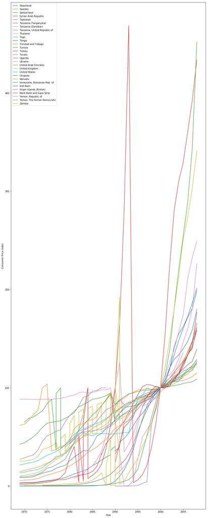

```python
# Plot the data by country.
plt.figure(figsize=(15, 40))
for country in (consumer_prices['Country or Area'].unique()[-30:-1]):
    plt.plot(consumer_prices.loc[(consumer_prices['Country or Area'] == country)].index.to_pydatetime(), consumer_prices['Value'].loc[consumer_prices['Country or Area'] == country], label=country)
    plt.xlabel('Year')
    plt.ylabel('Consumer Price Index')
    plt.legend()
```

First, filter the data to obtain the CPI values for the United States. You can then observe the pattern of the values changing over time (1969-2008) in the country.

```python
# CPI values in the United States.
us_consumer_prices = consumer_prices[['Value']].loc[consumer_prices['Country or Area'] == 'United States']
us_consumer_prices = us_consumer_prices.sort_index()
us_consumer_prices.head()
```

| Year | Value |
| --- | --- |
| 1969-01-01 | 21.293935 |
| 1970-01-01 | 22.554505 |
| 1971-01-01 | 23.524174 |
| 1972-01-01 | 24.299910 |
| 1973-01-01 | 25.812594 |

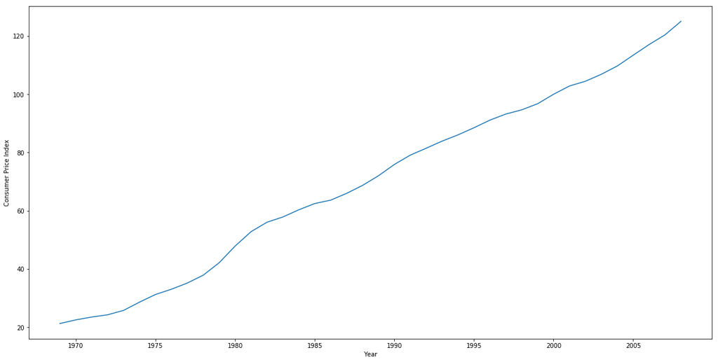

```python
# Plot time series data.
import matplotlib.dates as mdates
plt.figure(figsize=(20, 10))
plt.xlabel('Year')
plt.ylabel('Consumer Price Index')
plt.plot(us_consumer_prices.index.to_pydatetime(), us_consumer_prices['Value']);
```

## 2. Explore data

In this section, you will explore the data to learn more about the stationarity of the series and determine the steps to take for data preparation.

### 2.1 Checking stationarity of time series

You need to check the stationarity of the time series, since many models assume that the series is stationary. A time series is stationary when the mean, variance, and covariance of the data are constant and not dependent on time.

#### Seasonal Decomposition

You will use the `statsmodels` package to plot and model the time series data.

Decompose the time series to observe the trend and seasonality in the data.

```python
!pip install --upgrade statsmodels
```

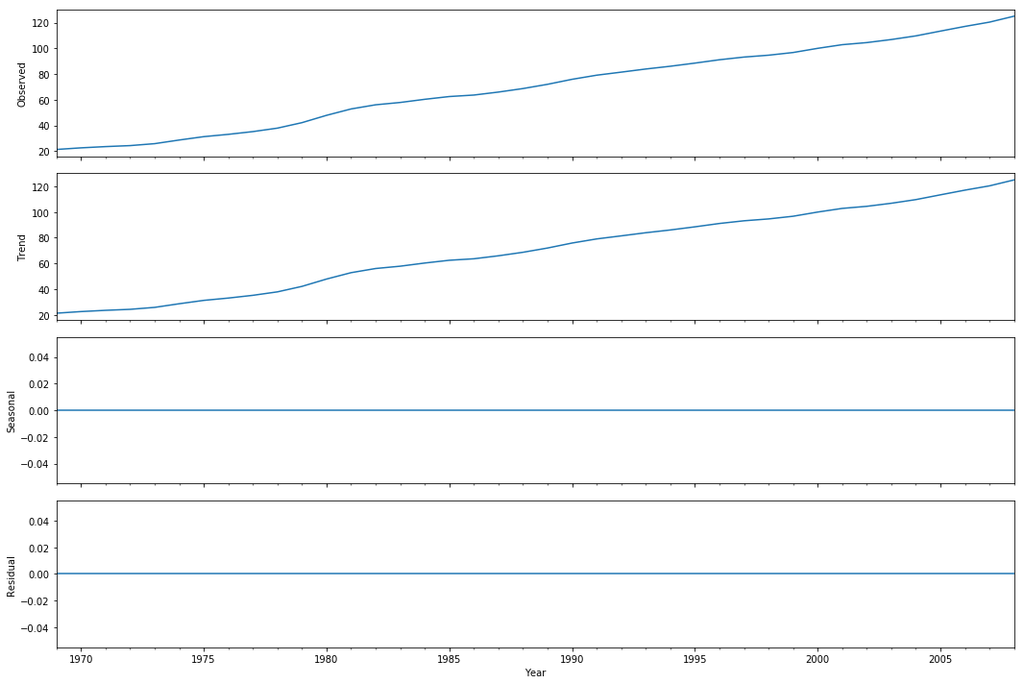

```python
# Decomposition of the time series data.
import numpy
import statsmodels.api as sm
from pylab import rcParams

rcParams['figure.figsize'] =15, 10
decomposition = sm.tsa.seasonal_decompose(us_consumer_prices['Value'], model = 'additive')
fig = decomposition.plot()
plt.xlabel('Year')
plt.show()
```

As you can see, the trend is changing based on time, so you can infer that the series is not stationary. You can also use another method, called the Dicky-Fuller test, to confirm this observation.

#### Dicky-Fuller Test

```python
# Augmented Dicky-Fuller test.
from statsmodels.tsa.stattools import adfuller
dftest = adfuller(us_consumer_prices['Value'], autolag='AIC')
dfoutput = pd.Series(dftest[0:4], index=['Test Statistic', 'p-value', 'Number of Lags Used', 'Number of Observations Used'])
for key,value in dftest[4].items():
    dfoutput['Critical Value (%s)'%key] = value
print(dfoutput)
```

```
Test Statistic                  0.640969
p-value                         0.988583
Number of Lags Used             2.000000
Number of Observations Used    37.000000
Critical Value (1%)            -3.620918
Critical Value (5%)            -2.943539
Critical Value (10%)           -2.610400
dtype: float64
```

You can use the Dicky-Fuller test to check the stationarity of the time series data.

The null hypothesis $H_{o}$ assumes that the time series is dependent on time (that it is non-stationary). Since the `Test Statistic` is larger than the `Critical Values`, we cannot reject the null hypothesis and understand that the series is **non-stationary**.

## 3. Prepare data

### 3.1 ACF & PACF plots

A common tool used to forecast time series data is the `ARIMA` (**A**uto **R**egressive **I**ntegrated **M**oving **A**verage) model. The model has 3 parameters

- `p` - the parameter associated with the Auto-Regressive part of the ARIMA model. You can use the **PACF (partial autocorrelation function)** plot to find the optimal value.
- `d` - the parameter associated with the Integration part of the ARIMA model. This is the **order of difference**, or the number of times the time series is differenced in order to stationarize the series.
- `q` - the parameter associated with the Moving Average part of the ARIMA model. You can use the **ACF (autocorrelation function)** plot to find the optimal value.

Here are the ACF and PACF plots of the original time series data.

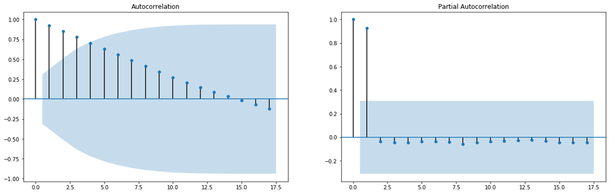

```python
# Visualize the ACF and PACF plots.
from statsmodels.graphics.tsaplots import plot_acf, plot_pacf
f, (ax1, ax2) = plt.subplots(1, 2, figsize=(20,6))
plot_acf(us_consumer_prices['Value'], ax = ax1)
plot_pacf(us_consumer_prices['Value'], ax = ax2, method='ywmle')
plt.show()
```

Since the series is not stationary, you will first use differencing before finding the parameters for the model.

### 3.2 Stationarizing the time series data

**Differencing** is used to remove the non-stationarity caused by the trend. The number of differences needed to remove stationarity determines the parameter `d`, for the Integration component of the ARIMA model. Run the following code to difference the data twice and plot the resulting values.

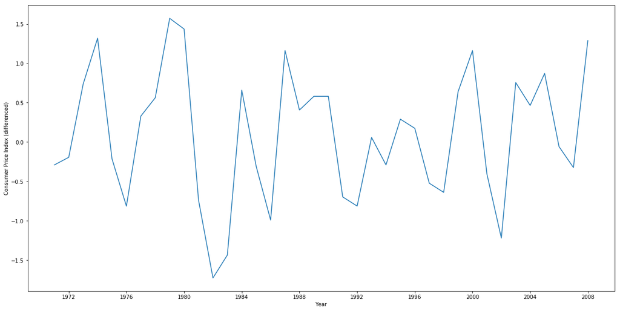

```python
# Differencing - remove non-stationarity.
plt.figure(figsize=(20, 10))
us_consumer_prices_dif = (((us_consumer_prices.diff()).dropna()).diff()).dropna()

plt.xlabel('Year')
plt.ylabel('Consumer Price Index (differenced)')
plt.plot(us_consumer_prices_dif['Value']);
```

The time series data has been differenced twice to remove stationarity. You can observe the trend of the modified data using the seasonal decomposition method once again.

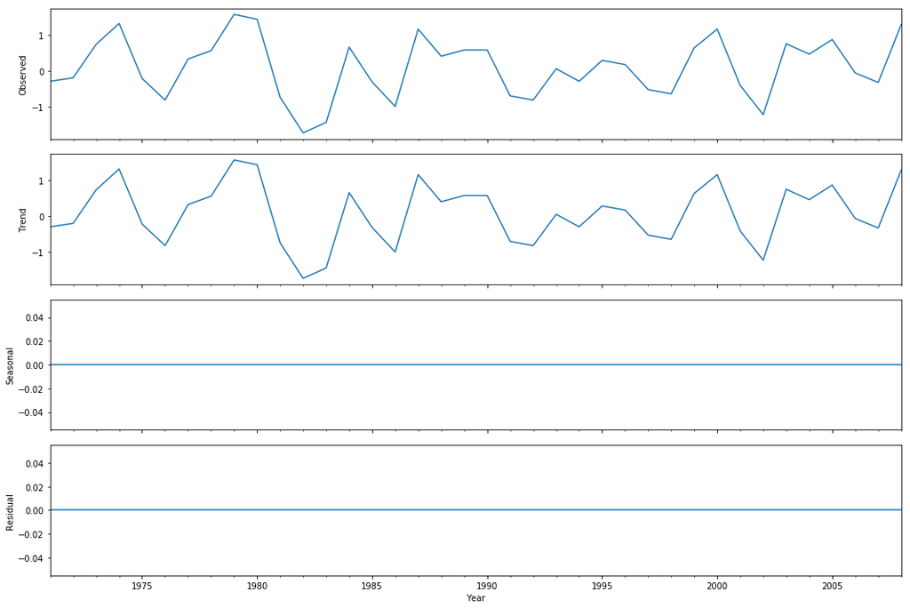

```python
# Decomposition of stationarized time series.
rcParams['figure.figsize'] = 15, 10
decomposition = sm.tsa.seasonal_decompose(us_consumer_prices_dif['Value'], model = 'additive')
fig = decomposition.plot()
plt.xlabel('Year')
plt.show()
```

From the plot, you can see that there is no observable trend or seasonality in the differenced time series data. Once again, you can use the Augmented Dicky-Fuller test to confirm that the stationarity of the data as well.

```python
# Augmented Dicky-Fuller test.
dftest = adfuller(us_consumer_prices_dif['Value'], autolag='AIC')
dfoutput = pd.Series(dftest[0:4], index=['Test Statistic', 'p-value', 'Number of Lags Used', 'Number of Observations Used'])
for key,value in dftest[4].items():
    dfoutput['Critical Value (%s)'%key] = value
print(dfoutput)
```

```
Test Statistic                -5.709087e+00
p-value                        7.370726e-07
Number of Lags Used            1.000000e+00
Number of Observations Used    3.600000e+01
Critical Value (1%)           -3.626652e+00
Critical Value (5%)           -2.945951e+00
Critical Value (10%)          -2.611671e+00
dtype: float64
```

Since the `Test Statistic` here is less than the `Critical Values`, we can reject the null hypothesis and we can assume that the series is stationary. As you can see from the decomposition plot and the Dicky-Fuller test, the stationarity has been removed.

## 4. Model Selection

Now, you can run the code below to plot the ACF and PACF plots of the modified stationary data.

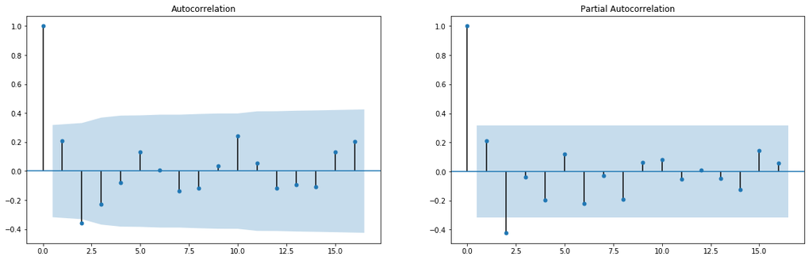

```python
# Visualize the ACF and PACF plots of the stationarized series.
f, (ax1, ax2) = plt.subplots(1, 2, figsize = (20, 6))
plot_acf(us_consumer_prices_dif['Value'], ax = ax1)
plot_pacf(us_consumer_prices_dif['Value'], ax = ax2, method='ywmle')
plt.show()
```

### 4.1 Grid Search

To check the optimal values for the ARIMA parameters, you can perform grid search using the package below.

```python
# Install the pmdarima package.
!pip install --upgrade pmdarima
```

```python
# Import auto-arima - grid search for ARIMA.
from pmdarima.arima import auto_arima
```

```python
# Perform grid search for the ARIMA model.
stepwise_model = auto_arima(us_consumer_prices[:'2000'], start_p=0, start_q=0, max_p=5, max_q=5, seasonal=False, d=2, D=0,
                            trace=True, suppress_warnings=True, error_action='ignore', stepwise=True)
print(stepwise_model.aic())
```

```
Fit ARIMA: order=(0, 2, 0); AIC=78.442, BIC=81.245, Fit time=0.007 seconds
Fit ARIMA: order=(1, 2, 0); AIC=77.673, BIC=81.876, Fit time=0.026 seconds
Fit ARIMA: order=(0, 2, 1); AIC=71.611, BIC=75.815, Fit time=0.020 seconds
Fit ARIMA: order=(1, 2, 1); AIC=72.600, BIC=78.205, Fit time=0.051 seconds
Fit ARIMA: order=(0, 2, 2); AIC=72.036, BIC=77.640, Fit time=0.264 seconds
Fit ARIMA: order=(1, 2, 2); AIC=nan, BIC=nan, Fit time=nan seconds
Total fit time: 0.384 seconds
71.61111442190239
```

### 4.2 Build the model

In order to build and evaluate a model, we need to split the data set into train and test sets. You can use years 1969-2000 as the training data, and 2001-08 as the test data.

#### Train the model

```python
# Fit the ARIMA model.
from statsmodels.tsa.arima_model import ARIMA

X = us_consumer_prices[:'2000']
X.index = pd.DatetimeIndex(X.index.values, freq=X.index.inferred_freq)
mod = ARIMA(X, order=(0, 2, 1))
mod_fit = mod.fit()
```

```python
# Summary of the model.
mod_fit.summary()
```

ARIMA Model Results

| Dep. Variable: | D2.Value | No. Observations: | 30 |
| --- | --- | --- | --- |
| Model: | ARIMA(0, 2, 1) | Log Likelihood | -32.806 |
| Method: | css-mle | S.D. of innovations | 0.712 |
| Date: | Fri, 25 Oct 2019 | AIC | 71.611 |
| Time: | 19:25:55 | BIC | 75.815 |
| Sample: | 01-01-1971 | HQIC | 72.956 |
|  | - 01-01-2000 |  |  |

|  | coef | std err | z | P>\|z\| | [0.025 | 0.975] |
| --- | --- | --- | --- | --- | --- | --- |
| const | 0.0717 | 0.224 | 0.319 | 0.752 | -0.368 | 0.511 |
| ma.L1.D2.Value | 0.7494 | 0.145 | 5.158 | 0.000 | 0.465 | 1.034 |

Roots

|  | Real | Imaginary | Modulus | Frequency |
| --- | --- | --- | --- | --- |
| MA.1 | -1.3345 | +0.0000j | 1.3345 | 0.5000 |

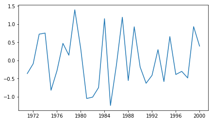

```python
# Plot the residuals.
plt.figure(figsize=(7, 4))
plt.plot(mod_fit.resid);
```

### 4.3 Forecasting

Now that you've built the model, you can use it to predict the Consumer Price Index for years 2001-08 and compare the predictions with the observed numbers. Run the code below to plot the observed values alongside the predicted values with a 95% confidence interval.

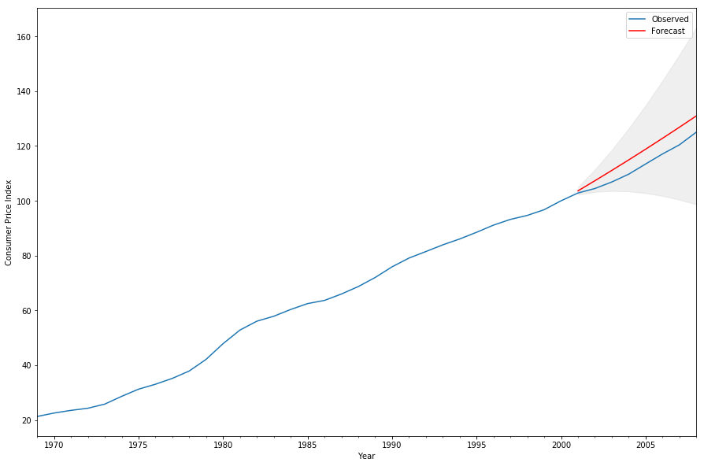

```python
# Predict on the test data.
ax = us_consumer_prices['1969':'2008'].plot(label='Observed')
forecast, stderr, conf_int = mod_fit.forecast(8, alpha = .05)
forecast = pd.DataFrame(forecast).set_index(us_consumer_prices['2001':].index)
forecast.plot(ax=ax, style = 'r', label='Forecast')

# Calculate and visualize the 95% confidence interval.
ax.fill_between(us_consumer_prices['2001':].index, conf_int[:,0], conf_int[:,1], color='dimgray', alpha=0.1)

# Add the labels to the plot.
plt.legend(('Observed', 'Forecast'))
plt.xlabel('Year')
plt.ylabel('Consumer Price Index');
```

In the plot above, you can observe how the predicted values (in red) measure up to the observed values (in blue) during the years 2001-08. As you can see, the time series model built in this notebook does a good job of predicting the Consumer Price Index in the United States close to the observed numbers.

## 5. Deploy model

In order to deploy a `custom model` that is not supported by the `IBM Watson Studio`, you msut write a `Python function` that trains the `custom model` inside the `score` function of the `Python function`.

### 5.1 Define Python function

Mainly, the `Python function` includes the steps described in section 4.2 Build the model and section 4.3 Forecasting. The `fit()` method and `forecast()` method are included in the `score` function of the `Python function`.

**Note**: If you are importing module(s) inside the Python function, you must install packages through the `subprocess` module.

```python
def arima_py_func():
    try:
        # Import the subprocess module.
        import subprocess

        # Install required packages.
        subprocess.check_output('pip install --user statsmodels', stderr=subprocess.STDOUT, shell=True)
    except subprocess.CalledProcessError as e:
        install_err = 'subprocess.CalledProcessError:\n\n' + 'cmd:\n' + e.cmd + '\n\noutput:\n' + e.output.decode()
        raise Exception('Installation failed:\n' + install_err)

    def score(payload):
        try:
            from statsmodels.tsa.arima_model import ARIMA

            mod = ARIMA(payload['values'][0], order=payload['order'])
            mod_fit = mod.fit()

            forecast, stderr, conf_int = mod_fit.forecast(
                payload['steps'],
                alpha=payload['alpha']
            )

            return {
                'fields': (
                    'forecast',
                    'stderr',
                    'conf_int'
                ),
                'predictions': (
                    forecast.tolist(),
                    stderr.tolist(),
                    conf_int.tolist()
                )
            }  # Make sure the return type is dict.
        except Exception as e:
            return {'error': repr(e)}

    return score
```

You will pass the optimal parameters found in section 4.1 Grid Search and parameters used in section 4.3 Forecasting to the deployed model.

```python
arima_order = (0, 2, 1)
arima_steps = 8
arima_alpha = .05
```

The sample data include the data that were used to train the model in section 4.2 Build the model.

```python
sample_data = {
    'fields': ['values'],
    'values': [
        us_consumer_prices[:'2000'].values.reshape(1, -1).tolist()[0]
    ],
    'order': arima_order,
    'steps': arima_steps,
    'alpha': arima_alpha
}
```

```python
arima_pf = arima_py_func()
```

Pass the sample data to the Python function.

```python
arima_pred = arima_pf(sample_data)
```

Print the prediction results.

```python
arima_pred
```

```
{'fields': ('forecast', 'stderr', 'conf_int'),
 'predictions': ([103.61841518710672,
   107.30849956368732,
   111.0702531297418,
   114.90367588527016,
   118.8087678302724,
   122.78552896474852,
   126.83395928869852,
   130.9540588021224],
  [0.7123675252174944,
   2.084082319757026,
   3.82279395234582,
   5.867238675830576,
   8.178115068596716,
   10.728044626990753,
   13.4966134544235,
   16.46786034862888],
  [[102.2222004939245, 105.01462988028894],
   [103.22377327614686, 111.39322585122778],
   [103.57771466282647, 118.56279159665714],
   [103.40409939194176, 126.40325237859857],
   [102.77995683439852, 134.83757882614628],
   [101.75894787130821, 143.81211005818884],
   [100.38108300476974, 153.2868355726273],
   [98.67764561637458, 163.23047198787023]])}
```

```python
print(arima_pred['fields'])
print(arima_pred['predictions'])
```

[output not shown]

### 5.2 Deploy custom model to the Watson Machine Learning repository

Authenticate the Watson Machine Learning service on the IBM Cloud.

**Tip**: Authentication information (your credentials) can be found in the [Service Credentials](https://dataplatform.cloud.ibm.com/docs/content/wsj/analyze-data/ml-get-wml-credentials.html) tab of the service instance that you created on the IBM Cloud.  
If you cannot find the **instance_id** field in **Service Credentials**, click **New credential (+)** to generate new authentication information.

**Action**: Enter your Watson Machine Learning service instance credentials here.

```python
wml_credentials = {
    'url': 'https://ibm-watson-ml.mybluemix.net',
    'username': '***',
    'password': '***',
    'instance_id': '***'
}
```

Import the `watson-machine-learning-client` module and authenticate the service instance.

```python
from watson_machine_learning_client import WatsonMachineLearningAPIClient
```

Instantiate a `WatsonMachineLearningAPIClient` object.

```python
client = WatsonMachineLearningAPIClient(wml_credentials)
```

Save the `Python function` in your Watson Machine Learning repository. First, you need to create the function metadata to store in the repository.

```python
# Function Metadata.
meta_props = {
    client.repository.FunctionMetaNames.NAME: 'ARIMA model python function'
}
```

You need the function uid to create the deployment. You can extract the function uid from the saved function details and use it to create the deployment.

```python
# Create the function artifact.
function_details = client.repository.store_function(meta_props=meta_props, function=arima_py_func)
function_uid = client.repository.get_function_uid(function_details)
print('Function UID = {}'.format(function_uid))
```

```
No matching default runtime found. Creating one...SUCCESS

Successfully created runtime with uid: 0a1b035f-0247-42b8-b382-b7c5a41fea87
Function UID = 69df5be6-b52d-4b70-be32-0d6507a5dd07
```

Print the saved function metadata from Watson Machine Learning.

```python
# Details about the function.
function_details = client.repository.get_details(function_uid)

from pprint import pprint
pprint(function_details)
```

[output not shown]

Deploy the `Python function` to the `Watson Machine Learning` repository.

```python
function_id = function_details['metadata']['guid']
function_deployment_details = client.deployments.create(artifact_uid=function_id, name='ARIMA model python function deployment')
```

```
#######################################################################################

Synchronous deployment creation for uid: '69df5be6-b52d-4b70-be32-0d6507a5dd07' started

#######################################################################################


INITIALIZING
DEPLOY_IN_PROGRESS.
DEPLOY_SUCCESS


------------------------------------------------------------------------------------------------
Successfully finished deployment creation, deployment_uid='11a1047c-46f6-4206-b15b-8e2a6eb9e517'
------------------------------------------------------------------------------------------------
```

Print deployment details.

```python
pprint(function_deployment_details)
```

[output not shown]

### 5.3 Score the model

Check the deployment endpoint url.

```python
function_deployment_endpoint_url = client.deployments.get_scoring_url(function_deployment_details)
function_deployment_endpoint_url
```

The following payload is the data that will be passed to the deployment endpoint url for scoring.

```python
payload = {
    'values': [
        us_consumer_prices[:'2000'].values.reshape(1, -1).tolist()[0]
    ],
    'order': arima_order,
    'steps': arima_steps,
    'alpha': arima_alpha
}
```

Score the model and obtain predictions.

```python
predictions = client.deployments.score(function_deployment_endpoint_url, payload)
```

```python
forecast = numpy.array(predictions['predictions'][0])
conf_int = numpy.array(predictions['predictions'][2])
```

Check if the predictions are the same by plotting the same graph described in section 4.3 Forecasting.

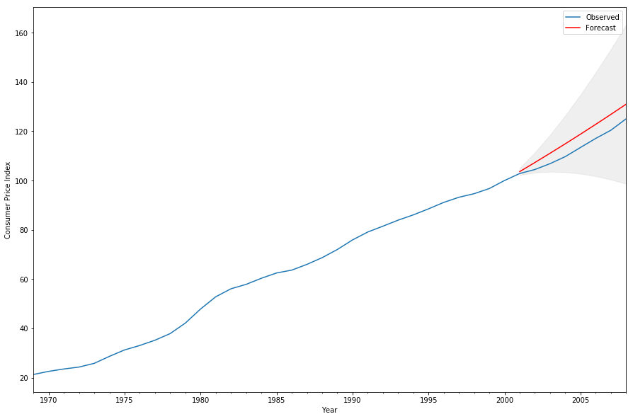

```python
ax = us_consumer_prices['1969':'2008'].plot(label='Observed')
forecast = pd.DataFrame(forecast).set_index(us_consumer_prices['2001':].index)
forecast.plot(ax=ax, style = 'r', label='Forecast')

# Calculate and visualize the 95% confidence interval.
ax.fill_between(us_consumer_prices['2001':].index, conf_int[:,0], conf_int[:,1], color='dimgray', alpha=0.1)

# Add the labels to the plot.
plt.legend(('Observed', 'Forecast'))
plt.xlabel('Year')
plt.ylabel('Consumer Price Index');
```

## 6. Summary and next steps

You successfully completed this notebook and learned how to create a Time Series model. You can now analyze a time series data to check its stationarity, stationarize the series if necessary, and find the optimal parameters for the ARIMA model. You've learned how to use this model to forecast data with a confidence interval.

You also learned how to deploy a non-supported model using a `Python function`.

Check out our [Online Documentation](https://dataplatform.ibm.com/docs/content/analyze-data/wml-setup.html) for more samples, tutorials, documentation, how-tos, and blog posts.

### Data citations

UNData: Consumer prices, general indices (2000=100). (2010). Retrieved from [http://data.un.org/](http://data.un.org/Data.aspx?d=LABORSTA&f=tableCode%3a7A).

Consumer Price Index: U.S. Bureau Of Labor Statistics. Retrieved from https://www.bls.gov/cpi/.

### Authors

**Ananya Kaushik** is a Data Scientist at IBM.  
**Jihyoung Kim** is a Data Scientist at IBM who strives to make data science easy for everyone through Watson Studio.

Copyright © 2019 IBM. This notebook and its source code are released under the terms of the MIT License.

Love this notebook? Don't have an account yet?  
Share it with your colleagues and help them discover the power of Watson Studio! [Sign Up](https://ibm.co/wsnotebooks)